# Introduction to ptLasso: drilling deeper

Erin Craig and Rob Tibshirani

Stanford University

2024-06-25

## Background

In Part 1, we learned about pretraining for the lasso, as it applies to “input grouped” data – data where each observation belongs to one of $k$ distinct groups (e.g. cancer classes). With simulated data, we saw how to fit pretrained models in this context using the R package `ptLasso`.

Now, we will show how to do pretraining for three different settings:

1. data with a multinomial response
2. multi-response data, and
3. time series data.

For all of these examples, we’ll use the `ptLasso` package - so let’s load it now.

```r
require(ptLasso)
```

In all cases, our modeling pipeline will look like this:

```r
# Data: features X, response y,
# and "useCase" (targetGroups, multiresponse or timeSeries)

# Fit a model:
fit = ptLasso(X, y, use.case = "useCase")
# ...optionally using cross-validation for parameter selection:
fit = cv.ptLasso(X, y, use.case = "useCase")

# Visualize the model:
plot(fit)

# And make predictions:
predict(fit, Xtest)

# And make predictions:
coef(fit, Xtest)
```

## Multinomial response data

- Multinomial response data has a *categorical* response: each response is in one of three or more categories. For example, observations may be from people with cancer, and our goal can be to predict the type of cancer.
- The pretraining philosophy for modeling data with a multinomial response is analogous to that for input grouped data.
- We wish to learn across all classes *and* learn a specific model for each class.
- We again use a two-stage training strategy.
1. **Fit an overall model**:

Fit a multinomial model using a group lasso penalty on the coefficients $\beta$.

*The group lasso penalty forces all responses to have the same support, but allows different coefficient values.*

2. **Fit group-specific models**:

Train individual one-vs-rest models using the penalty factor and offset defined by the overall model (as in the input grouped setting).

*This step allows us to discover features that are specific to each class.*

### Example with simulated data

First, simulate data:

```r
set.seed(1234)

n = 900  # number of observations
p = 100   # number of features
k = 3    # number of classes
class.sizes = rep(n/k, k) # size of each class
ncommon = 15  # number of shared features
nindiv = 10    # number of individual features
base.seq = seq(-.5, .5, length.out = ncommon + 1)
shift.common = matrix(
  c(sample(base.seq, ncommon), sample(base.seq, ncommon), sample(base.seq, ncommon)),
  nrow = 3
)
base.seq = seq(-.1, .1, length.out = nindiv + 1)
shift.indiv = matrix(
  c(sample(base.seq, nindiv), sample(base.seq, nindiv), sample(base.seq, nindiv)),
  nrow = 3
)
x     = matrix(rnorm(n * p), n, p)
xtest = matrix(rnorm(n * p), n, p)
y = ytest = c(sapply(1:length(class.sizes), function(i) rep(i, class.sizes[i])))

# Simulate our data.
# Shift x according to our coefficients, which differ by class.
start = ncommon + 1
for (i in 1:k) {
  end = start + nindiv - 1

  for(j in 1:ncommon){
    x[y == i, j] = x[y == i, j] + shift.common[i, j]
    xtest[ytest == i, j] = xtest[ytest == i, j] + shift.common[i, j]
  }
  jj = 1
  for(j in start:end){
    x[y == i, j] = x[y == i, j] + shift.indiv[i, jj]
    xtest[ytest == i, j] = xtest[ytest == i, j] + shift.indiv[i, jj]
    jj = jj + 1
  }

  start = end + 1
}
```

### Model fitting and visualization

Now we are ready to model.

By default, ptLasso uses `type.measure = "deviance"`, but for ease of interpretability, we use `type.measure = "class"` (the misclassification rate).

`ptLasso` uses `cv.glmnet` to fit $7$ models:

- the *overall* model (one multinomial model trained using all $3$ groups),
- the 3 *pretrained* models (a one-vs-rest model for each group) and
- the 3 *individual* models (a one-vs-rest model for each group).

```r
fit = ptLasso(x = x, y = y,
              use.case = "targetGroups",
              type.measure = "class",
              alpha = 0.5)

predict(fit, xtest, ytest = ytest)
```

```
##
## Call:
## predict.ptLasso(object = fit, xtest = xtest, ytest = ytest)
##
##
##
## alpha =  0.5
##
## Performance (Misclassification error):
##
##            overall   mean group_1 group_2 group_3
## Overall     0.3322
## Pretrain    0.3367 0.2267  0.1956  0.2633  0.2211
## Individual  0.3356 0.2337  0.2011  0.2633  0.2367
##
## Support size:
##
## Overall    28
## Pretrain   70 (16 common + 54 individual)
## Individual 50
```

Now, our performance metrics include:

- the “overall” misclassification rate, computed by treating this as a multinomial problem, and
- the “mean” and group-specific misclassification rates, computed by treating this as a set of one-vs-rest problems.

We can plot each of the models fitted:

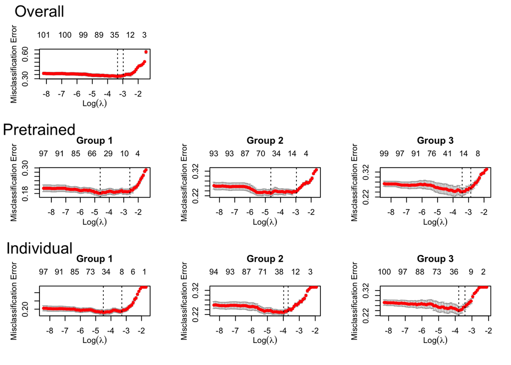

```r
plot(fit)
```

And extract coefficients:

```r
coefs = coef(fit)
```

### Choosing $\alpha$ with cross-validation

To choose the pretraining hyperparameter $\alpha$, we can use cross-validation. Plotting and predicting are done using the same syntax as before.

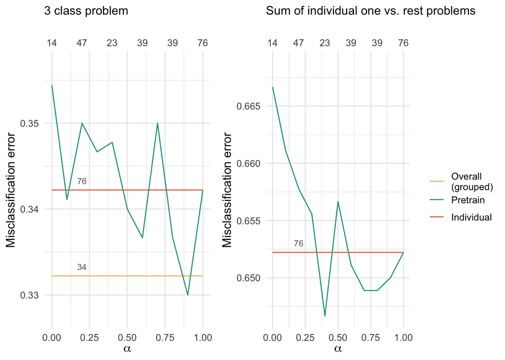

```r
set.seed(2345)
cvfit = cv.ptLasso(x = x, y = y,
              use.case = "targetGroups",
              type.measure = "class")

plot(cvfit)
```

```r
predict(cvfit, xtest, ytest = ytest)
```

```
##
## Call:
## predict.cv.ptLasso(object = cvfit, xtest = xtest, ytest = ytest)
##
##
##
## alpha =  0.9
##
## Performance (Misclassification error):
##
##            overall   mean group_1 group_2 group_3
## Overall     0.3344
## Pretrain    0.3367 0.2341  0.2067  0.2589  0.2367
## Individual  0.3489 0.2348  0.2089  0.2611  0.2344
##
## Support size:
##
## Overall    34
## Pretrain   33 (14 common + 19 individual)
## Individual 76
```

## Multi-response data

- Multi-response data has *multiple* responses for each observation. Data like this may come from a survey, where each person answered multiple questions. In this case, the people would be the observations and their answers would be the responses.
- `ptLasso` supports the special case where all responses are continuous (Gaussian).
- Pretraining for multi-response data is quite similar to the multinomial setting.
- We again wish to learn across all classes *and* learn a specific model for each class, and we use a two-stage training strategy.
1. **Fit an overall model**:

Fit a multi-response model using a group lasso penalty on the coefficients $\beta$.

2. **Fit response-specific models**:

Train individual models for each response, using the penalty factor and offset defined by the overall model.

- This is all done within `ptLasso`. Note that we only support data with multiple Gaussian responses.

### Example with simulated data

We start by simulating data with two Gaussian responses. The first 5 features are predictive for both responses; there is an extra set of 5 coefficients that are predictive for each individual response.

```r
set.seed(1234)

# Define constants
n = 1000         # Total number of samples
ntrain = 650     # Number of training samples
p = 500          # Number of features
sigma = 2        # Standard deviation of noise


# Generate covariate matrix
x = matrix(rnorm(n * p), n, p)

# Define coefficients for responses 1 and 2
beta1 = c(rep(1, 5), rep(0.5, 5), rep(0, p - 10))
beta2 = c(rep(1, 5), rep(0, 5), rep(0.5, 5), rep(0, p - 15))

mu = cbind(x %*% beta1, x %*% beta2)
y  = cbind(mu[, 1] + sigma * rnorm(n),
           mu[, 2] + sigma * rnorm(n))

# Split into train and test
xtest = x[-(1:ntrain), ]
ytest = y[-(1:ntrain), ]

x = x[1:ntrain, ]
y = y[1:ntrain, ]

cat("Correlation between two tasks:", cor(y[, 1], y[, 2]))
```

```
## Correlation between two tasks: 0.5119585
```

### Model fitting and visualization

```r
fit = ptLasso(x = x, y = y,
              use.case = "multiresponse",
              alpha = 0.5)

predict(fit, xtest, ytest = ytest)
```

```
##
## Call:
## predict.ptLasso(object = fit, xtest = xtest, ytest = ytest)
##
##
##
## alpha =  0.5
##
## Performance (Mean squared error):
##
##            allResponses  mean response_1 response_2
## Overall           9.217 4.608      4.092      5.125
## Pretrain          9.072 4.536      4.132      4.940
## Individual        9.324 4.662      4.168      5.157
##
## Support size:
##
## Overall    57
## Pretrain   23 (20 common + 3 individual)
## Individual 75
```

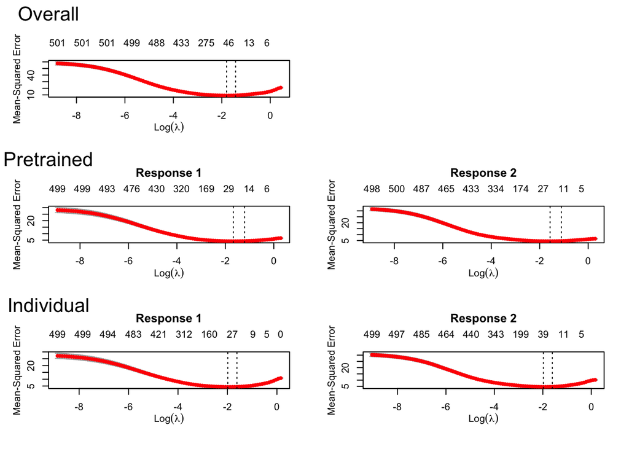

```r
plot(fit)
```

### Choosing $\alpha$ with cross-validation

```r
cvfit = cv.ptLasso(x = x, y = y,
                   use.case = "multiresponse")

predict(cvfit, xtest, ytest = ytest)
```

```
##
## Call:
## predict.cv.ptLasso(object = cvfit, xtest = xtest, ytest = ytest)
##
##
##
## alpha =  0.3
##
## Performance (Mean squared error):
##
##            allResponses  mean response_1 response_2
## Overall           9.217 4.608      4.092      5.125
## Pretrain          9.006 4.503      4.149      4.857
## Individual        9.324 4.662      4.168      5.157
##
## Support size:
##
## Overall    57
## Pretrain   22 (20 common + 2 individual)
## Individual 75
```

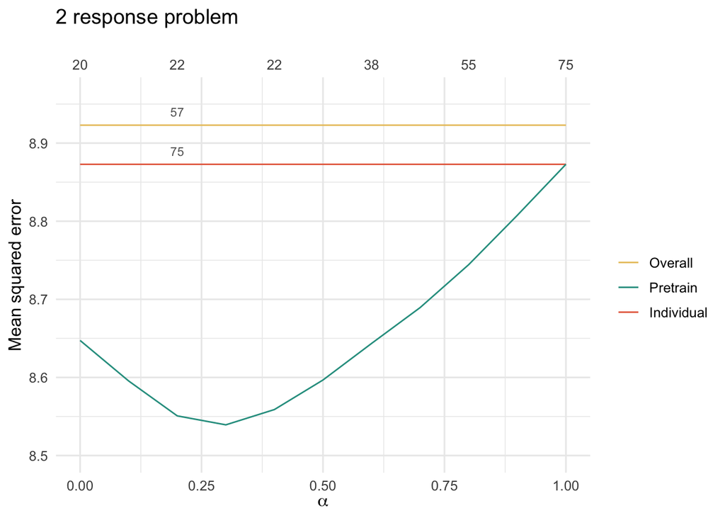

```r
plot(cvfit)
```

## Multi-response data with time ordered columns

- Here, we again have multiple responses for each observation. Now, however, these responses are measurements of the same outcome at different moments in *time*. For example, we may observe patients across many hospital visits, and measure the same biomarker at each visit. In this case, the time ordered biomarker measurements would be the responses.
- `ptLasso` has built-in support for data like this – we’ll call it time series data – where all responses are either Gaussian or binomial.
- We wish to leverage signal across time points *and* fit a model specifically tuned for each time point.
- To do pretraining with time series data, we:
1. **Fit an initial model**:

Fit a lasso penalized model for the first time point.

2. **Fit the next time-specific model**:

Train a model for time 2 using the penalty factor and offset defined by previous model.

3. **Continue**:

Train a model for time 3 using the offset from time 2 and the union of supports from times 1 and 2.

Train a model for time 4 using the offset from time 3 and the union of supports from times 1, 2 and 3.

etc.

### Example with simulated data

```r
set.seed(1234)

# Define constants
n = 600          # Total number of samples
ntrain = 300     # Number of training samples
p = 100          # Number of features
sigma = 2        # Standard deviation of noise

# Generate covariate matrix
x = matrix(rnorm(n * p), n, p)

# Define coefficients for time points 1 and 2
beta1 = c(rnorm(10), rep(0, p - 10))  # Coefs at time 1
beta2 = 0.5 * beta1 + c(rep(0, 10), runif(5, min = 0, max = 2), rep(0, p-15))

# Generate response variables for times 1 and 2
y = cbind(
  x %*% beta1 + sigma * rnorm(n),
  x %*% beta2 + sigma * rnorm(n)
)

# Split data into training and testing sets
xtest = x[-(1:ntrain), ]  # Test covariates
ytest = y[-(1:ntrain), ]  # Test response

x = x[1:ntrain, ]  # Train covariates
y = y[1:ntrain, ]  # Train response
```

### Model fitting and visualization

Modeling is just as before, only now we specify `use.case = "timeSeries"`.

Notice that our performance metrics no longer include an “Overall” model – we imagine that the alternative here is to just treat each time point separately. For Gaussian responses, one could alternatively try `use.case = "multiresponse"`. This ignores the time ordering of the responses, but is otherwise a valid approach to consider.

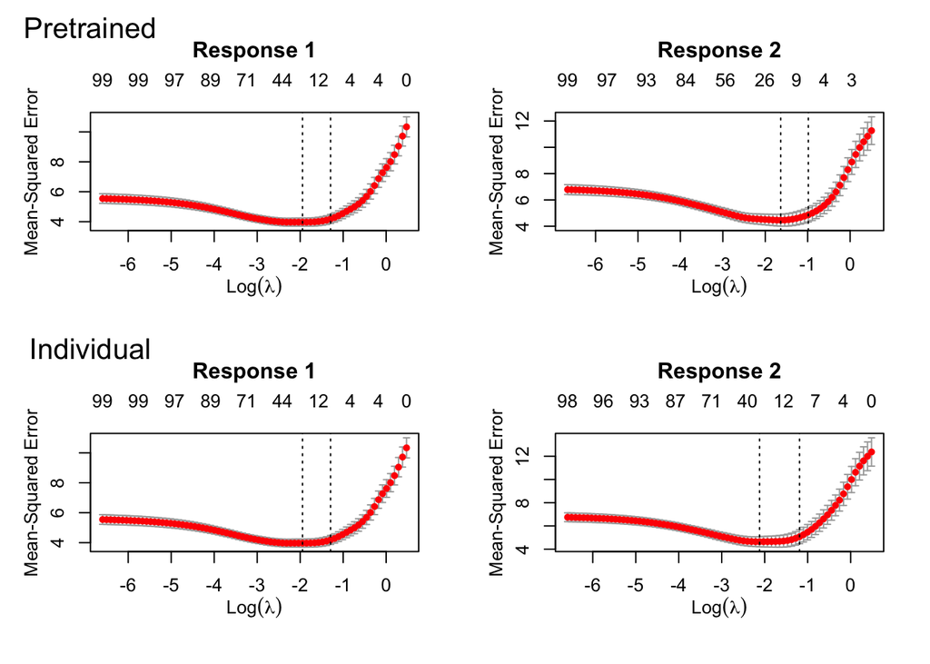

```r
fit = ptLasso(x = x, y = y,
              use.case = "timeSeries",
              alpha = 0.5)

plot(fit)
```

```r
predict(fit, xtest, ytest = ytest)
```

```
##
## Call:
## predict.ptLasso(object = fit, xtest = xtest, ytest = ytest)
##
##
##
## alpha =  0.5
##
## Performance (Mean squared error):
##
##             mean response_1 response_2
## Pretrain   4.706      4.554      4.859
## Individual 4.413      4.554      4.272
##
## Support size:
##
## Pretrain   35 (6 common + 29 individual)
## Individual 50
```

### Choosing $\alpha$ with cross-validation

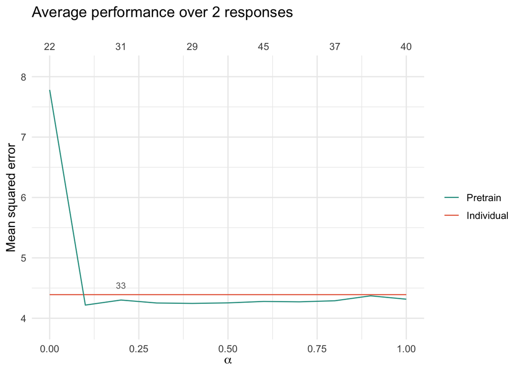

```r
set.seed(2345)
cvfit = cv.ptLasso(x = x, y = y,
                   use.case = "timeSeries")

plot(cvfit)
```

```r
predict(cvfit, xtest, ytest = ytest)
```

```
##
## Call:
## predict.cv.ptLasso(object = cvfit, xtest = xtest, ytest = ytest)
##
##
##
## alpha =  0.1
##
## Performance (Mean squared error):
##
##             mean response_1 response_2
## Pretrain   4.343      4.573      4.112
## Individual 4.502      4.573      4.431
##
## Support size:
##
## Pretrain   37 (8 common + 29 individual)
## Individual 33
```

## Wrap-up

Now we know how to do pretraining for all of the settings covered natively by `ptLasso`.

If you want to see more example use cases of pretraining – including conditional average treatment effect estimation and multi-response data with different outcome types – check out the `ptLasso` vignette!